# Penguins Exercise: Solutions

Samantha Ajovalasit

## 1) Clean all data from your Global Environment

```r
remove(list = ls())
```

## 2) Get from the library(palmerpenguins) the penguins dataset.

Note that you may need to install the library

## 3) Load library ggplot2, and type set.seed(1)

```r
library(dplyr)
```

```r
library(ggplot2)
library(palmerpenguins)
```

## Set also the seed = 1 this is not needed here.

```r
set.seed(1)
```

## 4) Load the dataset penguins ad a dataframe and name it

```r
peng <- (penguins)
```

Includes measurements for penguin species, island in Palmer Archipelago, size (flipper length, body mass, bill dimensions), and sex.

This is a subset of penguins_raw.

## 5) Convert it as a standard data.frame

Since it is a tibble (dataframe structure of tidyverse library) convert it as a standard data.frame

```r
peng <- as.data.frame(peng)
```

## 6) rint all summary informations

(dimensions, type of data, structure etc.)

```r
head(peng,10)
```

```
##    species    island bill_length_mm bill_depth_mm flipper_length_mm body_mass_g
## 1   Adelie Torgersen           39.1          18.7               181        3750
## 2   Adelie Torgersen           39.5          17.4               186        3800
## 3   Adelie Torgersen           40.3          18.0               195        3250
## 4   Adelie Torgersen             NA            NA                NA          NA
## 5   Adelie Torgersen           36.7          19.3               193        3450
## 6   Adelie Torgersen           39.3          20.6               190        3650
## 7   Adelie Torgersen           38.9          17.8               181        3625
## 8   Adelie Torgersen           39.2          19.6               195        4675
## 9   Adelie Torgersen           34.1          18.1               193        3475
## 10  Adelie Torgersen           42.0          20.2               190        4250
##       sex year
## 1    male 2007
## 2  female 2007
## 3  female 2007
## 4    <NA> 2007
## 5  female 2007
## 6    male 2007
## 7  female 2007
## 8    male 2007
## 9    <NA> 2007
## 10   <NA> 2007
```

```r
str(peng)
```

```
## 'data.frame':    344 obs. of  8 variables:
##  $ species          : Factor w/ 3 levels "Adelie","Chinstrap",..: 1 1 1 1 1 1 1 1 1 1 ...
##  $ island           : Factor w/ 3 levels "Biscoe","Dream",..: 3 3 3 3 3 3 3 3 3 3 ...
##  $ bill_length_mm   : num  39.1 39.5 40.3 NA 36.7 39.3 38.9 39.2 34.1 42 ...
##  $ bill_depth_mm    : num  18.7 17.4 18 NA 19.3 20.6 17.8 19.6 18.1 20.2 ...
##  $ flipper_length_mm: int  181 186 195 NA 193 190 181 195 193 190 ...
##  $ body_mass_g      : int  3750 3800 3250 NA 3450 3650 3625 4675 3475 4250 ...
##  $ sex              : Factor w/ 2 levels "female","male": 2 1 1 NA 1 2 1 2 NA NA ...
##  $ year             : int  2007 2007 2007 2007 2007 2007 2007 2007 2007 2007 ...
```

```r
summary(peng)
```

```
##       species          island    bill_length_mm  bill_depth_mm
##  Adelie   :152   Biscoe   :168   Min.   :32.10   Min.   :13.10
##  Chinstrap: 68   Dream    :124   1st Qu.:39.23   1st Qu.:15.60
##  Gentoo   :124   Torgersen: 52   Median :44.45   Median :17.30
##                                  Mean   :43.92   Mean   :17.15
##                                  3rd Qu.:48.50   3rd Qu.:18.70
##                                  Max.   :59.60   Max.   :21.50
##                                  NA's   :2       NA's   :2
##  flipper_length_mm  body_mass_g       sex           year
##  Min.   :172.0     Min.   :2700   female:165   Min.   :2007
##  1st Qu.:190.0     1st Qu.:3550   male  :168   1st Qu.:2007
##  Median :197.0     Median :4050   NA's  : 11   Median :2008
##  Mean   :200.9     Mean   :4202                Mean   :2008
##  3rd Qu.:213.0     3rd Qu.:4750                3rd Qu.:2009
##  Max.   :231.0     Max.   :6300                Max.   :2009
##  NA's   :2         NA's   :2
```

```r
nrow(peng)
```

```
## [1] 344
```

```r
ncol(peng)
```

```
## [1] 8
```

```r
names(peng)
```

```
## [1] "species"           "island"            "bill_length_mm"
## [4] "bill_depth_mm"     "flipper_length_mm" "body_mass_g"
## [7] "sex"               "year"
```

### 6.1)format the year as factor

```r
peng$year <- as.factor(peng$year)
```

### 6.2) print the mean of the column bill_length_mm

```r
mean(peng$bill_length_mm, na.omit=T)
```

```
## [1] NA
```

Why do we have to use na.omit?

## 7) Remove the NA rows from the dataset

```r
peng <- na.omit(peng)
```

### 8) Calculate the mean for male and female penguins of flipper length

Long way

```r
male_peng <- subset(peng,sex=='male')
female_peng <- subset(peng,sex=='female')

mean(male_peng$flipper_length_mm)
```

```
## [1] 204.506
```

```r
mean(female_peng$flipper_length_mm)
```

```
## [1] 197.3636
```

#second smarter way

```r
aggregate(.~sex, peng, mean)[6]
```

```
##   flipper_length_mm
## 1          197.3636
## 2          204.5060
```

#third smarter way

```r
tapply(peng$flipper_length_mm , peng$sex, mean)
```

```
##   female     male
## 197.3636 204.5060
```

Or you can use also by()

### 9) plot the histogram of the bill depth in mm and fill it by species

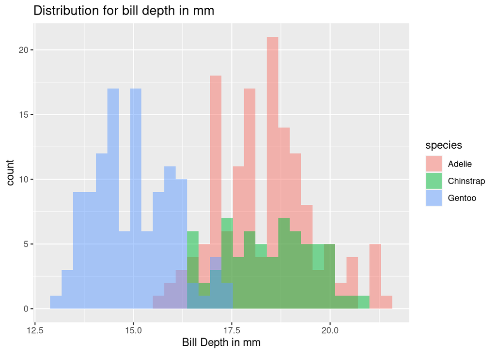

```r
ggplot(peng, aes(x = bill_depth_mm, fill = species)) +
  geom_histogram(position='identity', alpha=0.5)+
  ggtitle('Distribution for bill depth in mm')+
  xlab('Bill Depth in mm')
```

### 10) plot the bar of the body mass and divide it by sex, choice an appropriate width

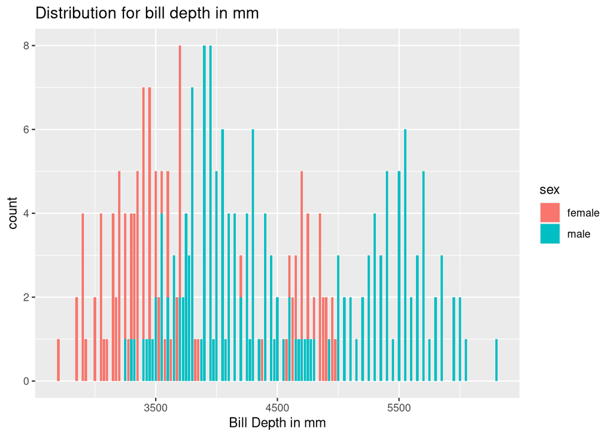

```r
ggplot(peng, aes(x = body_mass_g, fill=sex)) +
  geom_bar(position='identity',width = 20)+
  ggtitle('Distribution for bill depth in mm')+
  xlab('Bill Depth in mm')
```

### 11)plot the bar of the species and bill length, fill the bar by sex

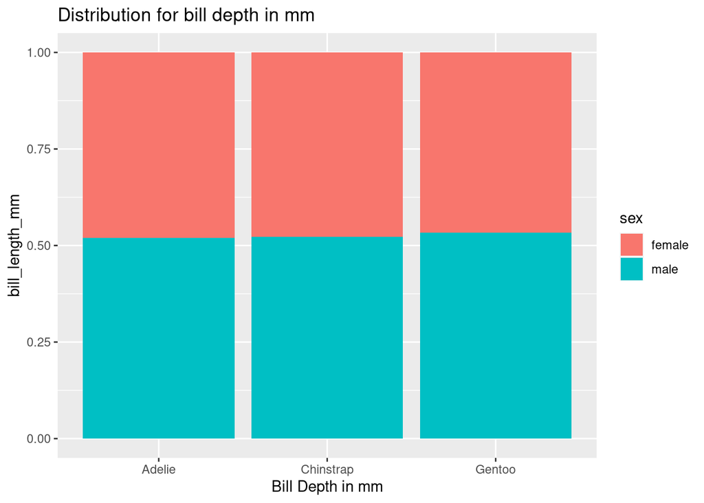

```r
ggplot(peng, aes(x = species, y=bill_length_mm, fill=sex)) +
  geom_col(position='fill')+
  ggtitle('Distribution for bill depth in mm')+
  xlab('Bill Depth in mm')
```

This way you have that the bill length is filled in a scale from 0 to 1 and not in absolute values (to plot in absolute value just drop position from col)

### 12) plot the points of bill lenght in x axis and bill dept in y axis,

#### color it by species and add shapes for island

#### put the x axis label at 35 degrees

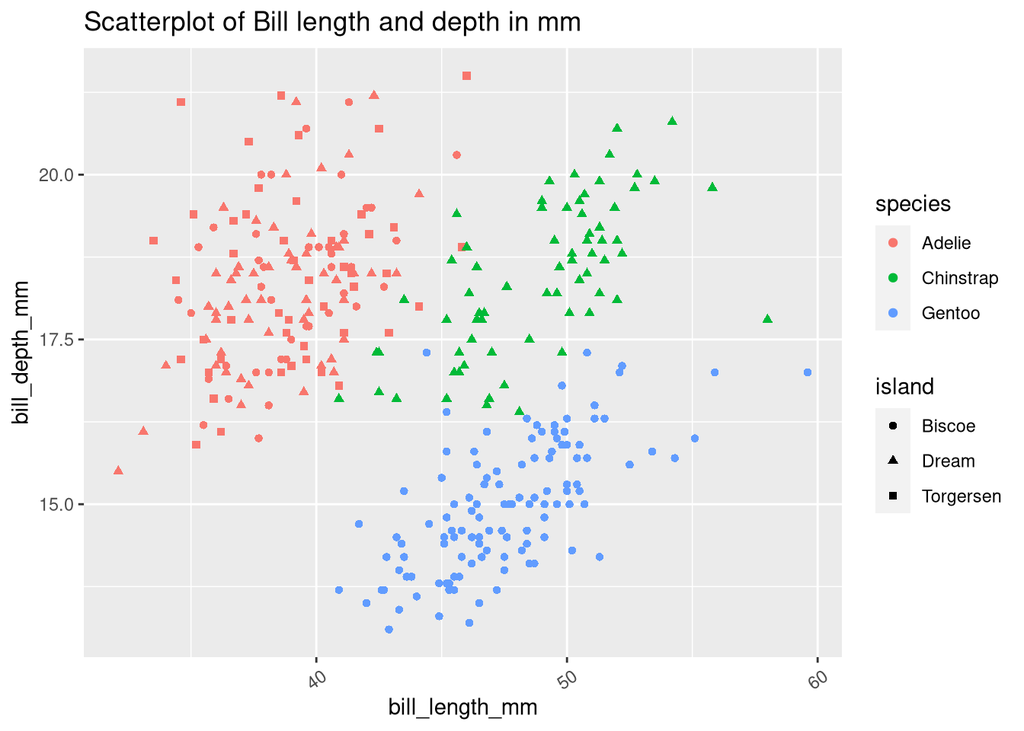

```r
ggplot(peng, aes(x = bill_length_mm, y=bill_depth_mm, color = species,shape=island)) +
  geom_point()+ggtitle('Scatterplot of Bill length and depth in mm')+
  theme(axis.text.x = element_text(angle = 35, vjust = .5 ))
```

#### 12.1) Now use a color scale gradient2 for the body mass, choose a color lower and high

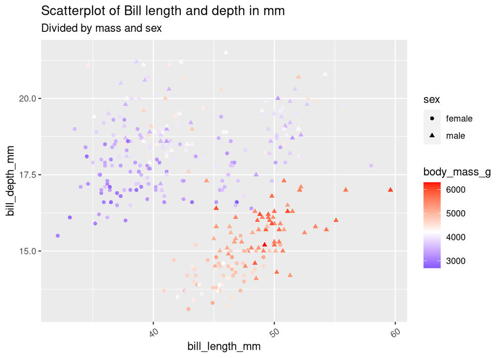

```r
meanbody <- mean(peng$body_mass_g)

ggplot(peng,aes(bill_length_mm, bill_depth_mm, color=body_mass_g,shape=sex))+ geom_point()+
  scale_color_gradient2(midpoint=meanbody, low="blue",                        high="red")+ggtitle('Scatterplot of Bill length and depth in mm',subtitle = 'Divided by mass and sex')+
  theme(axis.text.x = element_text(angle = 35, vjust = .5 ))
```

During the lecture we set the shape of body mass with a shape now we are doing the same with a gradient color

### 13) plot the boxplot of the body mass by sex and color it by island,

#### then facet by the species

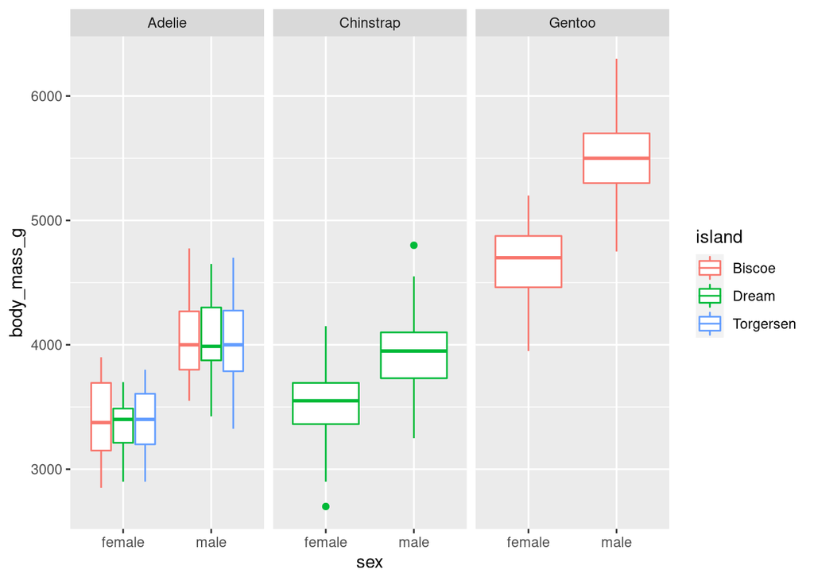

```r
box.plot <- ggplot(peng, aes(x=sex, y=body_mass_g, color=island)) +
  geom_boxplot()+facet_grid(~species)
box.plot
```

#### 13.1) add points to the boxplot

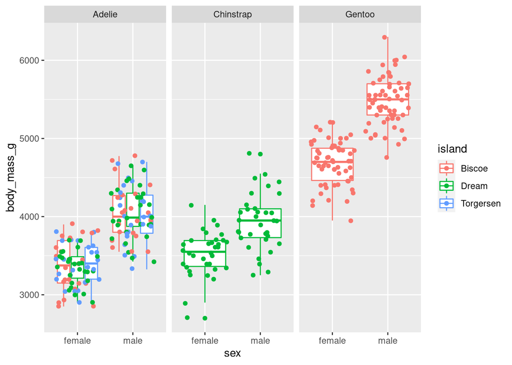

```r
box.plot+ geom_jitter()
```

Set correct width and alpha arguments

### 14) create a new factor variable called weight based on body mass of penguins where under the mean each sex is underweight and overweight

```r
male.weight <- mean(male_peng$body_mass_g)
female.weight <- mean(female_peng$body_mass_g)

peng$weight <- factor(ifelse(peng$body_mass_g <= male.weight & peng$sex=='male', 'underweight',
                             ifelse(peng$body_mass_g > male.weight & peng$sex=='male' , 'overweight',
                                    ifelse(peng$body_mass_g <= female.weight &peng$sex=='female','underweight', 'overweight'))))
```

#### 14.1) then redo a box plot by chosing appropriate variables

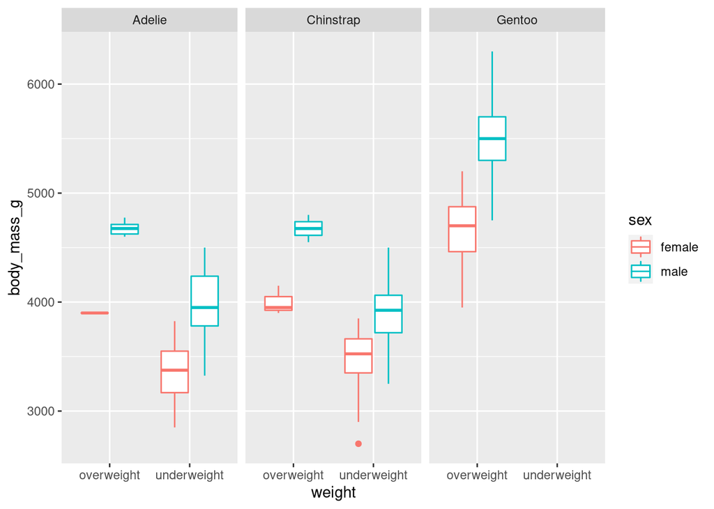

```r
box.plot <- ggplot(peng, aes(x=weight, y=body_mass_g, color=sex)) +
  geom_boxplot()+facet_grid(~species)
box.plot
```